# Servicios ecosistémicos

## Propuesta de trabajo para la Zonificación de la Milpa Peninsular

**CentroGeo Subsede Mérida**

*Rosa Martha Peralta Blanco*

### Introducción

El presente documento establece las bases y propone guías de acción para la elaboración de una Zonificación de la Milpa Peninsular a partir de la aplicación del método elaborado por SIPAM para el Estado de Yucatán, bajo el enfoque de la sustentabilidad milpera dentro de los servicios ecosistémicos.

Con base en ello, el primer paso consiste en la valoración de los servicios ecosistemicos. De esta forma y a modo de explicitar el flujo de generación del ejercicio, en primera instancia se definirá la Zonificación de la milpa para Yucatán; en segunda, se explicará el ejercicio conceptual de dichos servicios; en tercera, se describirá la forma en la que el valor se proporciona a cada unidad; y por último, a fin de optimizar el trabajo, la ruta metodológica sugerida para la vía de colaboración entre CG-CDMX y CG-MID.

### Zonificación de la Milpa en Yucatán

La delimitación de distintas areas milperas consiste básicamente en la división del territorio de Yucatán en *unidades* que permitan incentivar el uso consciente de los servicios ambientales que los ecosistemas del Estado proveen, minimizando de esta forma, el impacto ambiental y vulnerabilidad por las actividades antrópicas. Es decir, la zonificación se encamina a introducir el elemento "**Milpa**" como una entidad elemental y de retroalimentación de los sistemas ecosistémicos.

Los criterios tomados en cuenta para la valoración de servicios ambientales son:

1. Representación
2. Aportación
3. Distribución

De acuerdo a lo anterior la Zonificación se divide en dos áreas fundamentales:

- **Región Milpera**: Zona relacionada con la mayor disponibilidad de servicios ambientales de los que se enriquece la Milpa
- **Área de influencia**: Zona con servicios ambientales que dan "soporte" a la Milpa

A su vez, estas zonas se dividen en ambos casos, en dos subtipos:

- **Consolidación**: Espacios que se conservan y se encuentran favorecidos
- **Estabilización**: Espacios desfavorecidos antrópicamente y que deben ser estabilizados

A fin de tener un instrumento geográfico que satisfaga los aspectos mencionados, se eligió la representación cartográfica pertinente.

#### Unidad de Análisis espacial

La categoría espacial considerada fue la **Unidad de Gestión Ambiental** (UGA), la cual ha sido definida por el Programa de Ordenamiento Ecológico del Territorio del Estado de Yucatán (POETY). A continuación se muestra una visualización previa de las UGA's consideradas:

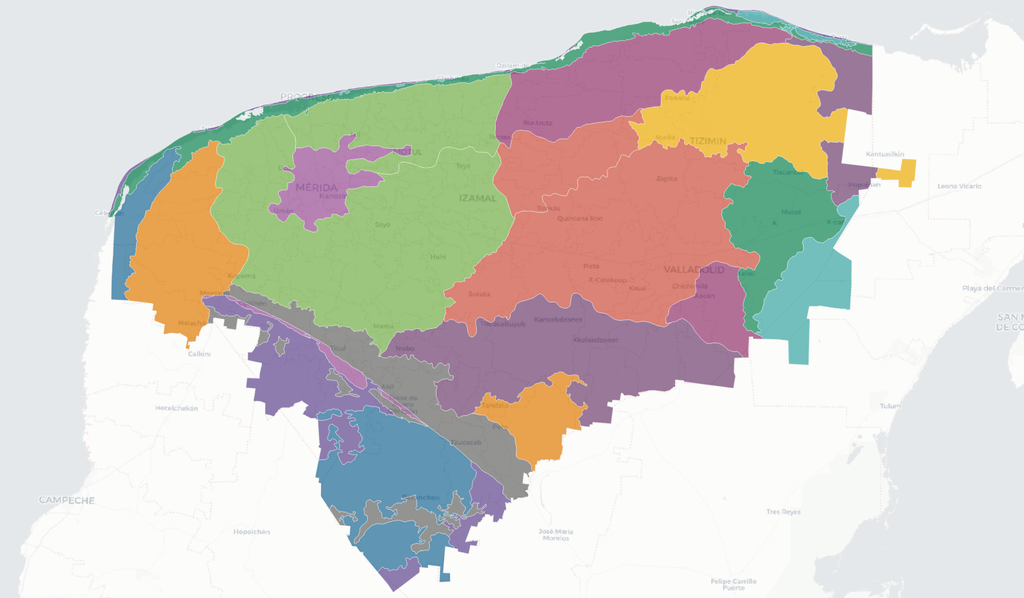

Las UGA's para el estado de Yucatan conforman 24 regiones, las cuales consideran mayoritariamente las características geomorfológicas del Estado

### Conceptualización de los servicios ecosistémicos

El estado de Yucatán contempla la amplia diversidad de productos que los servicios ambientales ofrecen , los cuales pueden o no ser tangibles para el ser humano.

Bajo este principio, se dividen en cuatro tipos:

1. **Provisión**: Entendidos como productos que el ser humano utiliza para la subsistencia
2. **Regulación**: Referidos a aquellos componentes que benefician a los componentes del ecosistema
3. **Soporte**: Considerados aquellos elementos útiles para la generación de más servicios ecosistémicos
4. **Culturales**: Definidos como piezas clave del ecosistema para la obtención de servicios intangibles (p. ej. recreativos)

*NOTA* *: Se propone el uso de pesos estadísticos para la valoración de los Sistemas en la adecuación del ejercicio*